# House Notebook

# 1.read file

```r
library(dplyr)
library(Hmisc)
```

```
Error in library(Hmisc) : 不存在叫‘Hmisc’这个名字的程辑包
```

```r
cq <- read.csv("cq2.csv",sep = ",", stringsAsFactors = FALSE)
cq <- cq[, -11]
names(cq) <- c('名字','户型','面积','朝向','装修','电梯','楼层','区域','价格(万元)','单价(平方米)')
head(cq)
```

|  | 名字 | 户型 | 面积 | 朝向 | 装修 | 电梯 | 楼层 | 区域 | 价格(万元) | 单价(平方米) |
| --- | --- | --- | --- | --- | --- | --- | --- | --- | --- | --- |
| 1 | 招商江湾城 | 4室2厅 | 175.91平米 | 东南 | 精装 | 有电梯 | 低楼层(共23层)2009年建板楼 | 北滨路 | 25 | 14497 |
| 2 | 帝豪怡庭 | 2室1厅 | 60.69平米 | 西 | 简装 | 有电梯 | 低楼层(共12层)2003年建塔楼 | 观音桥 | 53 | 8733 |
| 3 | 东原D7二期 | 2室2厅 | 81平米 | 东南 | 精装 | 有电梯 | 中楼层(共42层)2012年建塔楼 | 大石坝 | 95 | 11729 |
| 4 | 新城绿园 | 2室2厅 | 86.65平米 | 东 | 简装 | 有电梯 | 中楼层(共12层)2001年建塔楼 | 花卉园 | 65 | 7502 |
| 5 | 丰业小区 | 3室2厅 | 123平米 | 南 | 简装 | 无电梯 | 中楼层(共7层)2002年建塔楼 | 花卉园 | 70 | 5692 |
| 6 | 金科廊桥水岸 | 5室2厅 | 199.5平米 | 东南 | 精装 | 高楼层(共25层)2008年建板塔结合 | 海尔路 | 23 | 11930 | NA |

## clean the data, delete the rows with NA and delete the rows which is 别墅

```r
# delete the row with NA
cq2data <-na.omit(cq)
# delete 别墅 data
bieshuIndex  <- grep("..别墅",cq2data$户型)
cq2data <- cq2data[-bieshuIndex,]
head(cq2data)
```

|  | 名字 | 户型 | 面积 | 朝向 | 装修 | 电梯 | 楼层 | 区域 | 价格(万元) | 单价(平方米) |
| --- | --- | --- | --- | --- | --- | --- | --- | --- | --- | --- |
| 1 | 招商江湾城 | 4室2厅 | 175.91平米 | 东南 | 精装 | 有电梯 | 低楼层(共23层)2009年建板楼 | 北滨路 | 25 | 14497 |
| 2 | 帝豪怡庭 | 2室1厅 | 60.69平米 | 西 | 简装 | 有电梯 | 低楼层(共12层)2003年建塔楼 | 观音桥 | 53 | 8733 |
| 3 | 东原D7二期 | 2室2厅 | 81平米 | 东南 | 精装 | 有电梯 | 中楼层(共42层)2012年建塔楼 | 大石坝 | 95 | 11729 |
| 4 | 新城绿园 | 2室2厅 | 86.65平米 | 东 | 简装 | 有电梯 | 中楼层(共12层)2001年建塔楼 | 花卉园 | 65 | 7502 |
| 5 | 丰业小区 | 3室2厅 | 123平米 | 南 | 简装 | 无电梯 | 中楼层(共7层)2002年建塔楼 | 花卉园 | 70 | 5692 |
| 7 | 丰业小区 | 2室2厅 | 87平米 | 东北 | 精装 | 无电梯 | 低楼层(共12层)2002年建板楼 | 花卉园 | 58 | 6667 |

# 2. Start to analysis the data

## a. Type disturbution

```r
# load library
library(ggplot2)
# show the different type houses' frquency
type_freq <- data.frame(table(cq2data$户型))
type_p <- ggplot(data = type_freq, mapping = aes(x = reorder(Var1, -Freq),y = Freq)) + geom_bar(stat = 'identity', fill = 'steelblue') + theme(axis.text.x  = element_text(angle = 30, vjust = 0.5)) + xlab('户型') + ylab('套数')
```

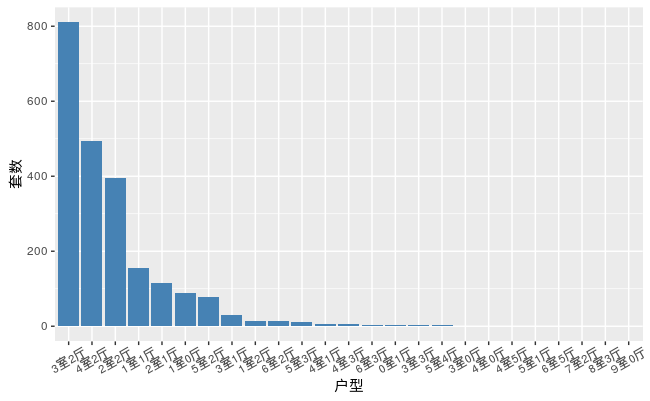

```r
type_p
```

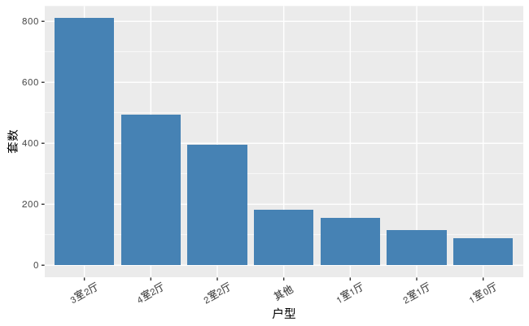

```r
type_tag <- c('3室2厅','4室2厅','2室2厅','1室1厅','2室1厅','1室0厅')
# 重新划分户型(三目运算符) 这里有点问题,先曲线酒国了
# as.character function can convert factor into charactor
hx <- as.character(cq2data$户型)
cq2data$type.new <- ifelse(hx  %in% type_tag, hx , '其他')
# 查看户型分布
type_freq <- data.frame(table(cq2data$type.new))
# 绘图
type_p <- ggplot(data = type_freq, mapping = aes(x = reorder(Var1, -Freq),y = Freq)) + geom_bar(stat = 'identity', fill = 'steelblue') + theme(axis.text.x  = element_text(angle = 30, vjust = 0.5)) + xlab('户型') + ylab('套数')
type_p
```

## b. Aera and unit_price distribution test

```r
# split the 面积 column and transfer str into numeric
cq2data$aera <- as.numeric(strsplit(cq2data$面积, "平米"))
```

> Aera normal distribution test

```
[1] "定量结果为： x不服从正态分布， P值 = 0 <= 0.05"

    Shapiro-Wilk normality test

data:  x
W = 0.921, p-value < 2.2e-16
```

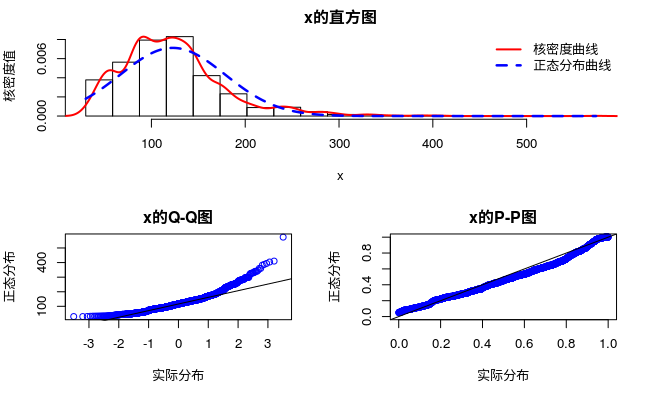

```r
source("norm.test.R")
norm.test(cq2data$aera)
```

> unit_price normal distribution test

```
[1] "定量结果为： x不服从正态分布， P值 = 0 <= 0.05"

    Shapiro-Wilk normality test

data:  x
W = 0.93127, p-value < 2.2e-16
```

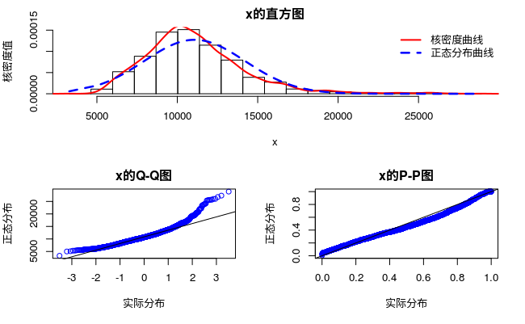

```r
norm.test(as.numeric(cq2data$`单价(平方米)`))
```

**As we can see from the plots above, the aera and unit_price do not satisfy the normal distribution**

## Floor distribution

```r
# split the data to get floor info
cq2data$floor <- substring(cq2data$楼层,1,3)
floor_freq <- table(cq2data$floor)
percent <- paste(round(prop.table(floor_freq)*100,2),'%', sep = '')
df <- data.frame(floor_freq)
df <- cbind(df, percent)
df
```

| Var1 | Freq | percent |
| --- | --- | --- |
| 低楼层 | 798 | 35.64% |
| 地下室 | 11 | 0.49% |
| 高楼层 | 743 | 33.18% |
| 中楼层 | 687 | 30.68% |

**As the data shows above, the percent of each floor type is almost the same, except for 地下室 !!!**

## Show the average unit_price of each aera in Chongqing

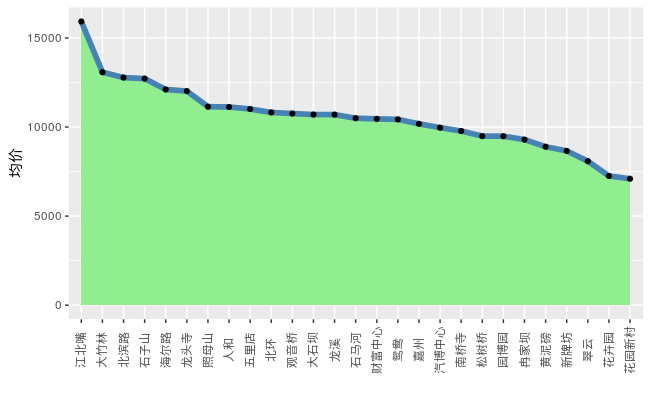

```r
# cal the average price
avg_price <- aggregate(cq2data$`单价(平方米)`, by = list(cq2data$区域), mean)
# plot
p <- ggplot(data = avg_price, mapping = aes(x = reorder(Group.1, -x), y = x, group = 1)) + geom_area(fill = 'lightgreen') + geom_line(colour = 'steelblue', size = 2) + geom_point() + xlab('') + ylab('均价') + theme(axis.text.x  = element_text(angle = 90, vjust = 0.5))
p
```

# 3. Build model

> Use K-means algorithm to clustering all the data 聚类原则：组内差距要小，组间差距要大 这里选择面积、房价和单价三个数值型变量

> a self-define function to show the cluster number

```r
tot.wssplot <- function(data, nc, seed=1234){
  #假设分为一组时的总的离差平方和
  tot.wss <- (nrow(data)-1)*sum(apply(data,2,var))
  for (i in 2:nc){
    #必须指定随机种子数
    set.seed(seed)
    tot.wss[i] <- kmeans(data, centers=i, iter.max = 100)$tot.withinss
  }
  plot(1:nc, tot.wss, type="b", xlab="Number of Clusters",
       ylab="Within groups sum of squares",col = 'blue',
       lwd = 2, main = 'Choose best Clusters')
}
```

**scale函数是将一组数进行处理，默认情况下是将一组数的每个数都减去这组数的平均值后再除以这组数的均方根。**

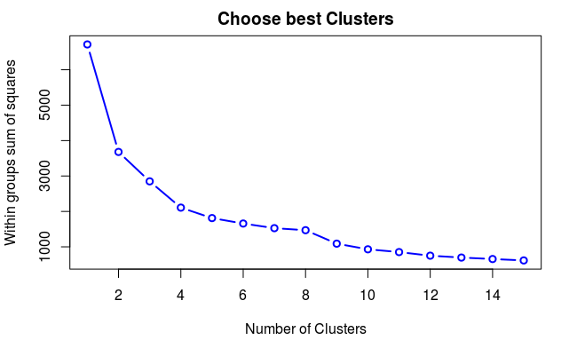

```r
standard_data <- data.frame(scale(cq2data[,c('aera','单价(平方米)','价格(万元)')]))
my.plot <- tot.wssplot(standard_data, nc=15)
```

## Use kmeans to cluster the cq2data

```r
set.seed(1234)
clust <- kmeans(x = standard_data, centers = 4, iter.max = 100)
table(clust$cluster)
```

```
  1   2   3   4
964 847 196 232
```

> show the region distribution by cluster result

```r
# show the region distribution by cluster result
table(cq2data$区域,clust$cluster)
```

```
             1   2   3   4
  北滨路    99  34   6  36
  北环       7   7   1   1
  财富中心   8   2   2   0
  翠云       0   1   0   0
  大石坝    80 110   4   6
  大竹林    32   2  13  10
  观音桥    61  99  13   7
  海尔路    15   9   0   1
  花卉园     4  64   5   0
  花园新村   1   9   1   0
  黄泥磅    16  24   8   0
  嘉州      17  21   8   3
  江北嘴    57   0   0  46
  龙头寺   108  42  18  24
  龙溪       5  19   0   1
  南桥寺     8  17   0   0
  汽博中心 115  53  44   9
  冉家坝    18  28   3   0
  人和      42  67  36  37
  石马河    62  45   1   7
  石子山    17  27   4  27
  松树桥     0  10   0   0
  五里店    58  37   8   5
  新牌坊    16  32   0   0
  鸳鸯      41  31   4   1
  园博园     6   0   0   0
  照母山    71  57  17  11
```

> cal the average aera of each type

```r
# cal the average aera of each type
aggregate(cq2data$aera, list(cq2data$type.new), mean)
```

| Group.1 | x |
| --- | --- |
| 1室0厅 | 44.66261 |
| 1室1厅 | 54.35013 |
| 2室1厅 | 70.42783 |
| 2室2厅 | 87.17197 |
| 3室2厅 | 127.14047 |
| 4室2厅 | 167.42543 |
| 其他 | 188.72967 |

> Compare the average aera, average price and average unit_price by cluster result

```r
aggregate(cq2data[,c('aera','单价(平方米)','价格(万元)')], list(clust$cluster), mean)
```

| Group.1 | aera | 单价(平方米) | 价格(万元) |
| --- | --- | --- | --- |
| 1 | 128.89528 | 11356.156 | 14.15041 |
| 2 | 78.79109 | 9276.758 | 70.37190 |
| 3 | 243.07582 | 9873.372 | 23.91327 |
| 4 | 155.85823 | 17511.806 | 28.06897 |

```r
p <- ggplot(data = cq2data[,c('aera','价格(万元)')], mapping = aes(x = 'aera',y = '价格(万元)', color = factor(clust$cluster)))
p
p <- p + geom_point(pch = 20, size = 3)
p + scale_colour_manual(values = c("red","blue", "green", "black", "orange",'purple'))
```

[output not shown]

```r
# 筛选出所有因子型变量
factors <- names(cq2data)[sapply(cq2data, class) == 'factor']
formula <- f <- as.formula(paste('~', paste(factors, collapse = '+')))
dummy <- dummyVars(formula = formula, data = cq2data)
```

```
错误: 没有"dummyVars"这个函数
```